# Modelo lineal general

##### Gráfico de modelo con variable predictora categórica

Con `plot_model()`:

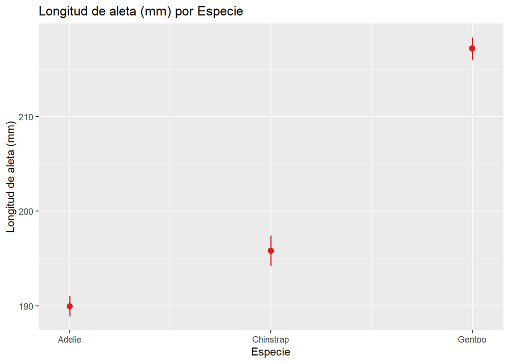

```r
plot_model(modelo2,
           type = "pred",
           terms = "species",
           title = "Longitud de aleta (mm) por Especie",
           axis.title = c("Especie", "Longitud de aleta (mm)"))
```

Para hacerlo con `ggplot()` primero debemos preparar los datos:

```r
pred <- ggpredict(modelo2, terms = "species")
pred <- rename(pred, species = x, flipper_length_mm = predicted)
```

[figure not shown]

```r
ggplot(pred, aes(species, flipper_length_mm)) +
  geom_point(size = 2) +
  geom_errorbar(aes(ymin = conf.low,
                    ymax = conf.high),
                width = 0.05) +
  labs(y = "Longitud de aleta (mm)",
       x = "Especie") +
  geom_text(aes(species,
                label = round(flipper_length_mm, digits = 2),
                hjust = -0.3)) +
  geom_signif(data = p,
              comparisons = list(c("Adelie", "Chinstrap"),
                                 c("Adelie", "Gentoo"),
                                 c("Chinstrap", "Gentoo")),
              y_position = c(197, 224, 220),
              tip_length = 0.01,
              map_signif_level = TRUE) +
  theme_bw()
```

Volver arriba

Inicio

#### Selección de modelos

Podemos generar varios modelos para determinar cuál de nuestras variables es la que mejor explica el comportamiento de nuestra variable respuesta.

```r
# modelo nulo (sin variable predictora)
modelo0 <- lm(flipper_length_mm ~ 1, data = p)

# modelos de regresión simple (una variable predictora)
modelo1 <- lm(flipper_length_mm ~ peso_kg, data = p)
modelo2 <- lm(flipper_length_mm ~ species, data = p)
modelo3 <- lm(flipper_length_mm ~ island, data = p)

# modelos de regresión múltiple (dos o más variables predictoras) aditivos
modelo4 <- lm(flipper_length_mm ~ species + peso_kg, data = p)
modelo5 <- lm(flipper_length_mm ~ island + peso_kg, data = p)
modelo6 <- lm(flipper_length_mm ~ species + island + peso_kg, data = p)

# modelos de regresión múltiple (dos o más variables predictoras) con interacción
modelo7 <- lm(flipper_length_mm ~ species * peso_kg, data = p)
modelo8 <- lm(flipper_length_mm ~ island * peso_kg, data = p)
modelo9 <- lm(flipper_length_mm ~ species * island * peso_kg, data = p)
```

Para comparar nuestros modelos y determinar cuál se ajusta mejor a nuestros datos utilizaremos el **criterio de información de Akaike (AIC)**.

Podemos realizar la comparación con la función `aictab()` del paquete `AICcmodavg`.

Para esta función debemos generar una lista con nuestros modelos y para facilitar la identificación también es recomendable generar un vector con los nombres de los modelos en el orden en que aparecen en la lista.

```r
modelos <- list(modelo0, modelo1, modelo2, modelo3, modelo4, modelo5, modelo6, modelo7, modelo8, modelo9)
nombres <- c("modelo0", "modelo1", "modelo2", "modelo3", "modelo4", "modelo5", "modelo6", "modelo7", "modelo8", "modelo9")
```

Ahora ejecutamos la función `aictab()`:

```r
aictab(modelos, nombres,
       second.ord = FALSE) # para que seleccione en base al AIC, si es TRUE selecciona en base al AICc (ajustado para muestras pequeñas)
```

```
##
## Model selection based on AIC:
##
##          K     AIC Delta_AIC AICWt Cum.Wt       LL
## modelo7  7 2125.42      0.00  0.62   0.62 -1055.71
## modelo9 11 2128.15      2.73  0.16   0.78 -1053.07
## modelo6  7 2128.52      3.10  0.13   0.92 -1057.26
## modelo4  5 2129.44      4.02  0.08   1.00 -1059.72
## modelo8  7 2260.41    134.99  0.00   1.00 -1123.21
## modelo2  4 2270.59    145.17  0.00   1.00 -1131.29
## modelo5  5 2288.47    163.05  0.00   1.00 -1139.24
## modelo1  3 2297.04    171.61  0.00   1.00 -1145.52
## modelo3  4 2624.39    498.97  0.00   1.00 -1308.20
## modelo0  2 2781.68    656.25  0.00   1.00 -1388.84
```

El resultado nos muestra lo siguiente:

- El nombre de los modelos ordenados de “mejor” a “peor”.
- **K** es el número de parámetros que tiene cada modelo.
- El valor de **AIC** indica el ajuste del modelo. Entre menor sea el valor de AIC, mejor se ajusta el modelo a nuestros datos. Si el resultado no muestra los modelos en orden, podemos especificarlo con el argumento `sort = TRUE`. No hay un valor de AIC estándar para decir que un modelo es bueno o malo, el valor de AIC dependerá de nuestros datos, el tamaño de muestra, la cantidad de parámetros y otros factores que conforman el criterio de información.
- **Delta_AIC** es la diferencia que hay entre los demás modelos respecto al primero. Modelos con un delta < 10 podrían considerarse como buenos modelos para explicar nuestros datos y deberíamos escoger entre ellos basándonos en nuestra experiencia sobre los datos.
- **AICWt** son los pesos de Akaike de cada modelo, indica cuánto explica cada modelo sobre la variación de nuestros datos (se transforma a pocentaje).
- **Cum.Wt** son los pesos acumulados
- **LL** es el logarítmo de la verosimilitud (log-likelihood) de cada modelo, este es uno de los parámetros en los que se basa el criterio de información de Akaike para calificar los modelos.

También podemos realizar la comparación entre modelos con la función `compare_performance()` del paquete `performance`. Con esta función no es necesario crear una lista con nuestros modelos ni un vector con los nombres:

```r
cp <- compare_performance(modelo0, modelo1, modelo2, modelo3, modelo4, modelo5, modelo6, modelo7, modelo8, modelo9,
                          rank = T)
cp
```

```
## # Comparison of Model Performance Indices
##
## Name    | Model |    R2 | R2 (adj.) |   RMSE |  Sigma | AIC weights
## -------------------------------------------------------------------
## modelo7 |    lm | 0.857 |     0.855 |  5.301 |  5.348 |       0.624
## modelo4 |    lm | 0.854 |     0.853 |  5.364 |  5.395 |       0.084
## modelo9 |    lm | 0.860 |     0.856 |  5.260 |  5.339 |       0.160
## modelo6 |    lm | 0.856 |     0.854 |  5.325 |  5.373 |       0.133
## modelo8 |    lm | 0.788 |     0.785 |  6.458 |  6.515 |    3.03e-30
## modelo2 |    lm | 0.778 |     0.777 |  6.612 |  6.642 |    1.87e-32
## modelo5 |    lm | 0.768 |     0.766 |  6.768 |  6.808 |    2.45e-36
## modelo1 |    lm | 0.759 |     0.758 |  6.893 |  6.913 |    3.39e-38
## modelo3 |    lm | 0.376 |     0.372 | 11.092 | 11.141 |   2.78e-109
## modelo0 |    lm | 0.000 |     0.000 | 14.041 | 14.062 |   1.96e-143
##
## Name    | AICc weights | BIC weights | Performance-Score
## --------------------------------------------------------
## modelo7 |        0.641 |       0.135 |            87.89%
## modelo4 |        0.093 |       0.837 |            75.02%
## modelo9 |        0.130 |    1.61e-05 |            63.70%
## modelo6 |        0.136 |       0.029 |            63.46%
## modelo8 |     3.12e-30 |    6.55e-31 |            50.91%
## modelo2 |     2.14e-32 |    1.27e-30 |            50.14%
## modelo5 |     2.72e-36 |    2.45e-35 |            49.25%
## modelo1 |     3.97e-38 |    1.56e-35 |            48.61%
## modelo3 |    3.18e-109 |   1.89e-107 |            22.05%
## modelo0 |    2.33e-143 |   6.15e-140 |             0.00%
```

Aquí los modelos están evaluados tomando en cuenta sus índices, como el ajuste a los datos con el **R cuadrado** y **R cuadrado ajustado**, su error con el **RMSE** y el **Sigma** (Error estándar residual), los **pesos de Akaike**, **pesos de Akaike ajustado para muestras pequeñas** y los **pesos del criterio de información Bayesiano**.

Con el argumento `rank = T` se crea una columna con la **Puntuación del rendimiento** de cada modelo generada a partir de la normalización de los índices de los modelos.

Podemos graficar el rendimiento de los modelos aplicando la función `plot()` al objeto que contiene la comparación realizada con `compare_performance()`. Esto genera un gráfico de “tela de araña” con el rendimiento de cada modelo respecto a los índices de comparación.

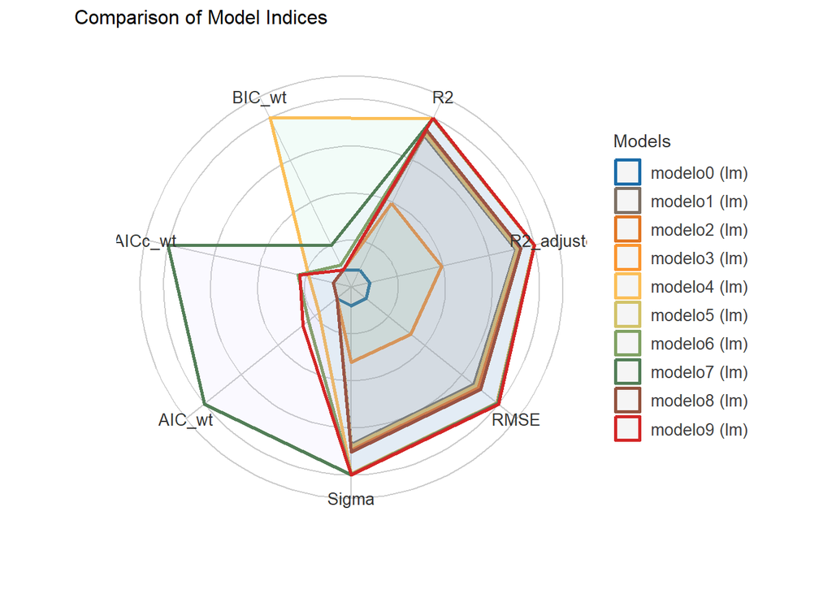

```r
plot(cp)
```

```r
# Los mejores modelos se muestran como las redes más extendidas (cercanas al borde de la circunferencia) en referencia a los índices.
```

Otra función para seleccionar modelos es `AICtab()` del paquete `bbmle`:

```r
AICtab(modelo0, modelo1, modelo2, modelo3, modelo4, modelo5, modelo6, modelo7, modelo8, modelo9,
       base = TRUE, # para que muestre el valor de AIC
       delta = TRUE, # para que muestre la diferencia entre modelos
       sort = TRUE, # para que ordene los modelos de "mejor" a "peor"
       weights = TRUE, # para que muestre los pesos de Akaike
       nobs = 333) # solo por si el tamaño de muestra es pequeño, colocamos el número de observaciones del conjunto de datos, si es un tamaño de muestra pequeño, con el argumento `base = TRUE` se mostrará el valor de AICc y no de AIC.
```

```
##         AIC    dAIC   df weight
## modelo7 2125.4    0.0 7  0.624
## modelo9 2128.1    2.7 11 0.160
## modelo6 2128.5    3.1 7  0.133
## modelo4 2129.4    4.0 5  0.084
## modelo8 2260.4  135.0 7  <0.001
## modelo2 2270.6  145.2 4  <0.001
## modelo5 2288.5  163.1 5  <0.001
## modelo1 2297.0  171.6 3  <0.001
## modelo3 2624.4  499.0 4  <0.001
## modelo0 2781.7  656.3 2  <0.001
```

##### Revisión del mejor modelo

Cuando seleccionamos el mejor modelo con los criterios antes mencionados debemos confirmar si cumple los supuestos de un modelo lineal y ver sus coeficientes para interpretarlo.

##### Revisión de supuestos del mejor modelo

```r
# normalidad de los residuales
cn <- check_normality(modelo7)
cn
```

```
## OK: residuals appear as normally distributed (p = 0.097).
```

```
## For confidence bands, please install `qqplotr`.
```

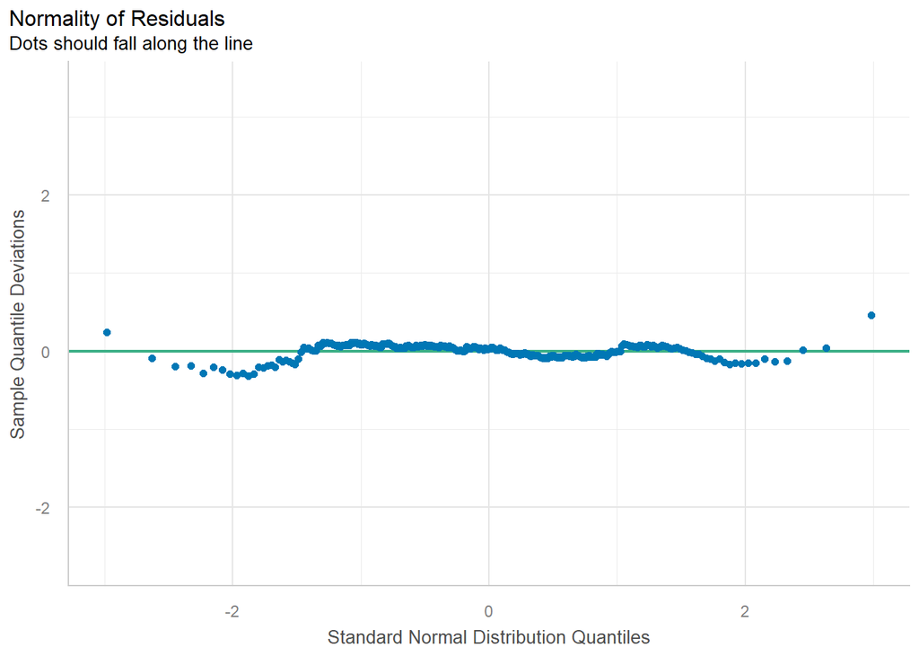

```r
plot(cn)
```

```r
# homogeneidad de la varianza de los residuales
ch <- check_heteroscedasticity(modelo7)
ch
```

```
## OK: Error variance appears to be homoscedastic (p = 0.061).
```

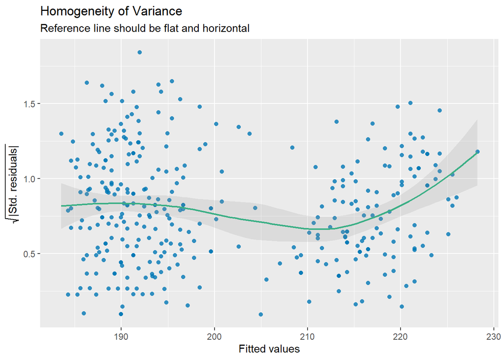

```r
plot(ch)
```

```r
# ausencia de observaciones influyentes
co <- check_outliers(modelo7)
co
```

```
## OK: No outliers detected.
## - Based on the following method and threshold: cook (0.7).
## - For variable: (Whole model)
```

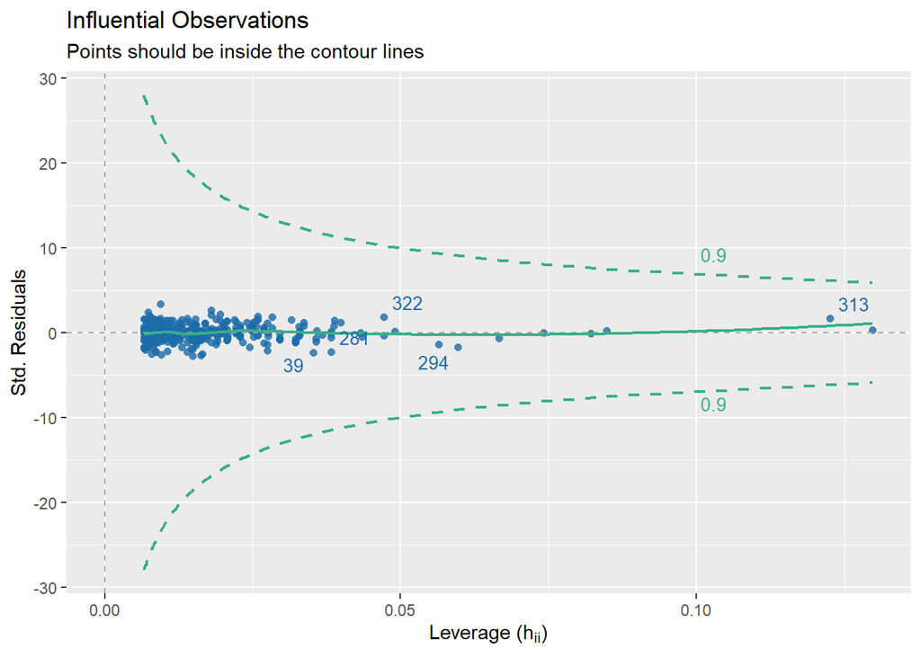

```r
plot(co)
```

##### Coeficientes y ajuste del mejor modelo

```r
summary(modelo7)
```

```
##
## Call:
## lm(formula = flipper_length_mm ~ species * peso_kg, data = p)
##
## Residuals:
##      Min       1Q   Median       3Q      Max
## -14.4296  -3.3494   0.1719   3.3428  18.0477
##
## Coefficients:
##                          Estimate Std. Error t value Pr(>|t|)
## (Intercept)              165.2448     3.5509  46.536  < 2e-16 ***
## speciesChinstrap         -13.8639     7.3013  -1.899  0.05844 .
## speciesGentoo              6.0594     6.0509   1.001  0.31735
## peso_kg                    6.6769     0.9523   7.011  1.3e-11 ***
## speciesChinstrap:peso_kg   5.2282     1.9486   2.683  0.00766 **
## speciesGentoo:peso_kg      2.3623     1.3526   1.746  0.08164 .
## ---
## Signif. codes:  0 '***' 0.001 '**' 0.01 '*' 0.05 '.' 0.1 ' ' 1
##
## Residual standard error: 5.348 on 336 degrees of freedom
## Multiple R-squared:  0.8575, Adjusted R-squared:  0.8553
## F-statistic: 404.2 on 5 and 336 DF,  p-value: < 2.2e-16
```

```r
parameters(modelo7)
```

```
## Parameter                     | Coefficient |   SE |           95% CI | t(336) |      p
## ---------------------------------------------------------------------------------------
## (Intercept)                   |      165.24 | 3.55 | [158.26, 172.23] |  46.54 | < .001
## species [Chinstrap]           |      -13.86 | 7.30 | [-28.23,   0.50] |  -1.90 | 0.058
## species [Gentoo]              |        6.06 | 6.05 | [ -5.84,  17.96] |   1.00 | 0.317
## peso kg                       |        6.68 | 0.95 | [  4.80,   8.55] |   7.01 | < .001
## species [Chinstrap] × peso kg |        5.23 | 1.95 | [  1.40,   9.06] |   2.68 | 0.008
## species [Gentoo] × peso kg    |        2.36 | 1.35 | [ -0.30,   5.02] |   1.75 | 0.082
```

```
##
## Uncertainty intervals (equal-tailed) and p-values (two-tailed) computed
##   using a Wald t-distribution approximation.
```

```r
performance(modelo7)
```

```
## # Indices of model performance
##
## AIC    |   AICc |    BIC |    R2 | R2 (adj.) |  RMSE | Sigma
## ------------------------------------------------------------
## 2125.4 | 2125.8 | 2152.3 | 0.857 |     0.855 | 5.301 | 5.348
```

##### Gráfico del mejor modelo

Podemos graficar el modelo con la función `plot_model()` del paquete `sjPlot` y combinarlo con argumentos de `ggplot2` para modificarlo:

```
## Ignoring unknown labels:
## • linetype : "peso kg"
## • shape : "peso kg"
```

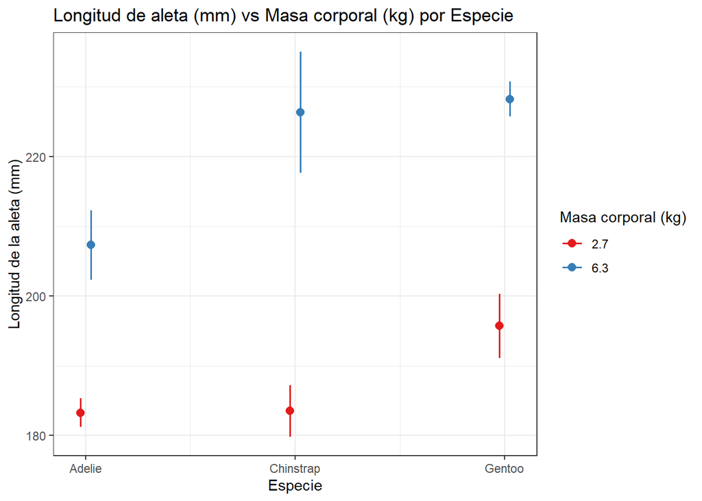

```r
plot_model(modelo7,
           type = "int", # "int", argumento para graficar la interacción entre las variables
           terms = c("species", "peso_kg")) + # argumento para indicar las variables predictoras.
  labs(title = "Longitud de aleta (mm) vs Masa corporal (kg) por Especie",
       y = "Longitud de la aleta (mm)",
       x = "Especie",
       color = "Masa corporal (kg)") + # para el título de la leyenda (color de los símbolos)
  theme_bw()
```

Podemos observar la **interacción entre las variables** “Especie” y “Masa corporal” que determina la “Longitud de la aleta”, aquí el gráfico muestra el valor mínimo y el valor máximo de la masa corporal de los pingüinos de la tabla de datos. La interacción se observa porque la masa corporal está influyendo en la longitud de la aleta para cada especie. Si la masa corporal no influyera, los valores de longitud de aleta tendrían la misma tendencia o patrón tanto para el valor mínimo como para el valor máximo de la masa corporal para cada especie.

Algo importante es que el **orden** en que coloquemos las variables predictoras en nuestro modelo afectará la salida del gráfico, especialmente si tenemos variables predictoras numéricas y categóricas.

El gráfico anterior es para el modelo: *lm(flipper_length_mm ~ species * peso_kg, data = p)*, que tiene las variables predictoras “Especie” (categórica) y “Masa corporal (numérica) en ese orden.

Si cambiamos el orden de las variables predictoras, los coeficientes del modelo serán los mismos (no afecta el resultado ni la interpretación del modelo), pero el gráfico será diferente:

```r
modelo7b <- lm(flipper_length_mm ~ peso_kg * species, data = p)
```

Comparemos los coeficientes:

```r
parameters(modelo7)
```

```
## Parameter                     | Coefficient |   SE |           95% CI | t(336) |      p
## ---------------------------------------------------------------------------------------
## (Intercept)                   |      165.24 | 3.55 | [158.26, 172.23] |  46.54 | < .001
## species [Chinstrap]           |      -13.86 | 7.30 | [-28.23,   0.50] |  -1.90 | 0.058
## species [Gentoo]              |        6.06 | 6.05 | [ -5.84,  17.96] |   1.00 | 0.317
## peso kg                       |        6.68 | 0.95 | [  4.80,   8.55] |   7.01 | < .001
## species [Chinstrap] × peso kg |        5.23 | 1.95 | [  1.40,   9.06] |   2.68 | 0.008
## species [Gentoo] × peso kg    |        2.36 | 1.35 | [ -0.30,   5.02] |   1.75 | 0.082
```

```r
parameters(modelo7b)
```

```
## Parameter                     | Coefficient |   SE |           95% CI | t(336) |      p
## ---------------------------------------------------------------------------------------
## (Intercept)                   |      165.24 | 3.55 | [158.26, 172.23] |  46.54 | < .001
## peso kg                       |        6.68 | 0.95 | [  4.80,   8.55] |   7.01 | < .001
## species [Chinstrap]           |      -13.86 | 7.30 | [-28.23,   0.50] |  -1.90 | 0.058
## species [Gentoo]              |        6.06 | 6.05 | [ -5.84,  17.96] |   1.00 | 0.317
## peso kg × species [Chinstrap] |        5.23 | 1.95 | [  1.40,   9.06] |   2.68 | 0.008
## peso kg × species [Gentoo]    |        2.36 | 1.35 | [ -0.30,   5.02] |   1.75 | 0.082
```

Los coeficientes siguen siendo los mismos y lo único que cambia es el orden en que aparece el coeficiente para la variable “peso kg”.

Ahora hagamos el gráfico:

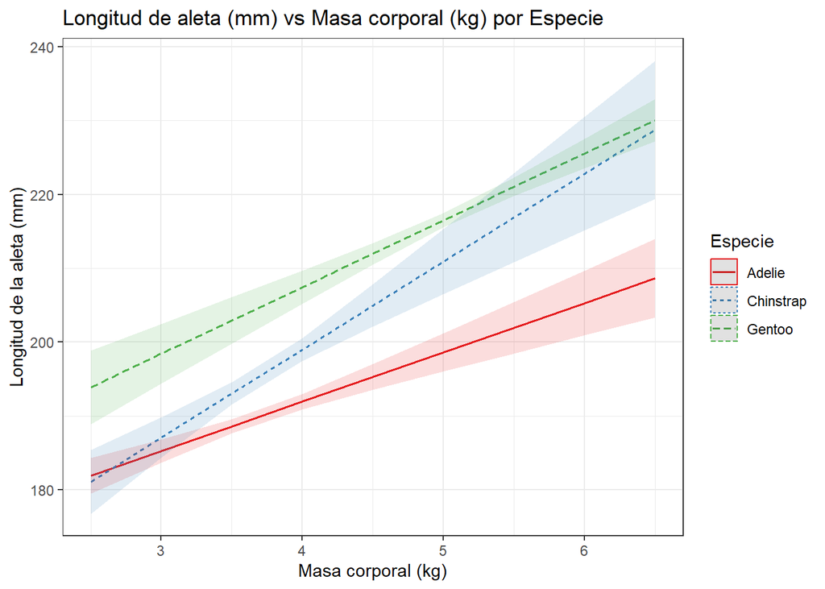

```r
plot_model(modelo7b,
           type = "int",
           terms = c("peso_kg", "species")) +
  aes(linetype = group, # para que el tipo de linea sea diferente para cada especie
      color = group, # color de linea diferente para cada especie
      fill = group) + # relleno de los intervalos de confianza diferente para cada especie
  labs(title = "Longitud de aleta (mm) vs Masa corporal (kg) por Especie",
       y = "Longitud de la aleta (mm)",
       x = "Masa corporal (kg)",
       color = "Especie",
       linetype = "Especie",
       fill = "Especie") + # para que color, linetype y fill estén en una sola leyenda y no en una cada uno.
  theme_bw()
```

Ahora tenemos un gráfico de líneas con intervalos de confianza (uno para cada especie). Este gráfico es más apropiado para interpretar el efecto en la variable respuesta cuando hay una variable predictora numérica.

Se puede apreciar la **interacción entre las variables** porque las líneas predichas por el modelo para la longitud de aleta de cada especie no son paralelas e incluso llegan a cruzarse (traslapan). Esto indica que **una variable predictora está influenciada por la otra** y esa interacción determina el efecto que tienen sobre la variable respuesta.

También podemos generar el gráfico utilizando la salida de la función `ggpredict()` del paquete `ggeffects` como entrada para los argumentos de `ggplot2`:

```r
g <- ggpredict(modelo7b,
               terms = c("peso_kg", "species"))
g
```

```
## # Predicted values of flipper_length_mm
##
## species: Adelie
##
## peso_kg | Predicted |         95% CI
## ------------------------------------
##    2.50 |    181.94 | 179.53, 184.34
##    3.00 |    185.28 | 183.71, 186.84
##    4.00 |    191.95 | 190.93, 192.98
##    4.50 |    195.29 | 193.57, 197.02
##    5.00 |    198.63 | 196.05, 201.21
##    6.50 |    208.64 | 203.33, 213.96
##
## species: Chinstrap
##
## peso_kg | Predicted |         95% CI
## ------------------------------------
##    2.50 |    181.14 | 176.83, 185.46
##    3.00 |    187.10 | 184.33, 189.86
##    4.00 |    199.00 | 197.44, 200.56
##    4.50 |    204.95 | 202.09, 207.82
##    5.00 |    210.91 | 206.48, 215.33
##    6.50 |    228.76 | 219.42, 238.10
##
## species: Gentoo
##
## peso_kg | Predicted |         95% CI
## ------------------------------------
##    2.50 |    193.90 | 188.94, 198.86
##    3.00 |    198.42 | 194.39, 202.46
##    4.00 |    207.46 | 205.22, 209.70
##    4.50 |    211.98 | 210.54, 213.42
##    5.00 |    216.50 | 215.54, 217.46
##    6.50 |    230.06 | 227.21, 232.91
```

```
##
## Not all rows are shown in the output. Use `print(..., n = Inf)` to show
##   all rows.
```

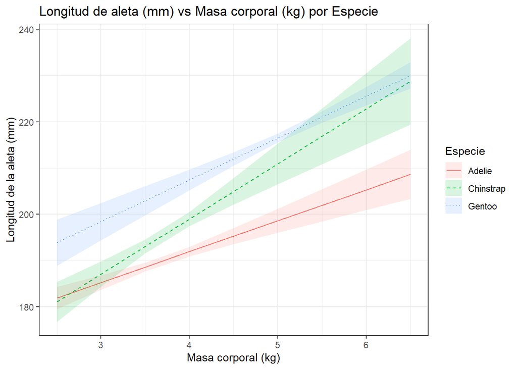

```r
ggplot(g, aes(x, predicted)) +
    geom_line(aes(linetype = group,
                  color = group)) +
    geom_ribbon(aes(ymin = conf.low, # para graficar el intervalo de confianza
                    ymax = conf.high,
                    fill = group),
                alpha = 0.15) +
    scale_linetype_manual(values = c("solid", "dashed", "dotted")) + # para especificar un tipo de línea diferente para cada especie
  theme_bw() +
  labs(title = "Longitud de aleta (mm) vs Masa corporal (kg) por Especie",
       x = "Masa corporal (kg)",
       y = "Longitud de la aleta (mm)",
       linetype = "Especie",
       color = "Especie",
       fill = "Especie")
```

Volver arriba

Inicio

#### Contraste entre niveles (medias)

En los parámetros del modelo todos los coeficientes están comparados contra el intercepto. La especie 2 y la especie 3 se comparan con la especie 1, pero no hay comparación entre la especie 2 y la especie 3.

Para generar la comparación podemos aplicar la función `estimate_contrast()` del paquete `modelbased`:

```r
estimate_contrasts(modelo7b,
                   "species") # indicamos la variable que contiene los grupos
```

```
## Marginal Contrasts Analysis
##
## Level1    | Level2    | Difference |   SE |         95% CI | t(336) |      p
## ----------------------------------------------------------------------------
## Chinstrap | Adelie    |       8.10 | 1.21 | [ 5.72, 10.49] |   6.68 | < .001
## Gentoo    | Adelie    |      15.99 | 1.16 | [13.70, 18.27] |  13.73 | < .001
## Gentoo    | Chinstrap |       7.88 | 1.41 | [ 5.10, 10.66] |   5.58 | < .001
##
## Variable predicted: flipper_length_mm
## Predictors contrasted: species
## Predictors averaged: peso_kg (4.2)
## p-values are uncorrected.
```

Como este es un modelo con interacción, el contraste está tomando en cuenta una masa corporal constante para todas las especies, pero sí considera su influencia en la longitud de la aleta.

El resultado no es el mismo que tendría un modelo simple con la especie como variable predictora nada más, como el modelo 2: *lm(flipper_length_mm ~ species, data = p)*:

```r
estimate_contrasts(modelo2,
                   "species")
```

```
## Marginal Contrasts Analysis
##
## Level1    | Level2    | Difference |   SE |         95% CI | t(339) |      p
## ----------------------------------------------------------------------------
## Chinstrap | Adelie    |       5.87 | 0.97 | [ 3.96,  7.78] |   6.05 | < .001
## Gentoo    | Adelie    |      27.23 | 0.81 | [25.65, 28.82] |  33.76 | < .001
## Gentoo    | Chinstrap |      21.36 | 1.00 | [19.39, 23.34] |  21.29 | < .001
##
## Variable predicted: flipper_length_mm
## Predictors contrasted: species
## p-values are uncorrected.
```

En este sentido, realizar los contrastes entre medias es más útil cuando tenemos modelos sencillos con variables predictoras categóricas, ya que podemos interpretar los contrastes más fácilmente.

También podemos hacer los contrastes de la siguiente manera:

Primero calculamos las medias de cada especie (en este caso serían las medias de la longitud de aleta) con la función `emmeans()` del paquete `emmeans` indicando la variable para la que se quiere ver las medias.

```r
medias <- emmeans(modelo2,
                  "species")
medias
```

```
##  species   emmean    SE  df lower.CL upper.CL
##  Adelie       190 0.540 339      189      191
##  Chinstrap    196 0.805 339      194      197
##  Gentoo       217 0.599 339      216      218
##
## Confidence level used: 0.95
```

Ahora realizamos la comparacion por pares (contrastes; diferencia entre medias) con la funcion `pairs()` del paquete base:

```r
contraste <- pairs(medias)
contraste
```

```
##  contrast           estimate    SE  df t.ratio p.value
##  Adelie - Chinstrap    -5.87 0.970 339  -6.052 <0.0001
##  Adelie - Gentoo      -27.23 0.807 339 -33.760 <0.0001
##  Chinstrap - Gentoo   -21.36 1.000 339 -21.286 <0.0001
##
## P value adjustment: tukey method for comparing a family of 3 estimates
```

Podemos ver los intervalos de confianza aplicamos la funcion `confint()` del paquete base:

```r
confint(contraste)
```

```
##  contrast           estimate    SE  df lower.CL upper.CL
##  Adelie - Chinstrap    -5.87 0.970 339    -8.15    -3.59
##  Adelie - Gentoo      -27.23 0.807 339   -29.13   -25.33
##  Chinstrap - Gentoo   -21.36 1.000 339   -23.73   -19.00
##
## Confidence level used: 0.95
## Conf-level adjustment: tukey method for comparing a family of 3 estimates
```

Y podemos graficar el contraste con la función `plot()`.

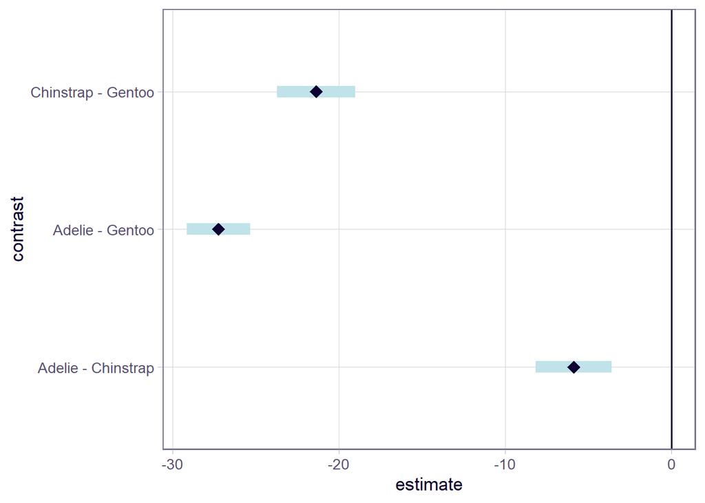

```r
plot(contraste) +
  geom_vline(xintercept = 0) # para agregar una línea vertical en el 0 del eje x
```

Como ninguno de los intervalos de confianza de los contrastes traslapa con la línea del cero, todas las diferencias entre las medias son estadísticamente significativas.

Para observar el caso de un contraste entre medias que no es estadísticamente significativo haremos lo mismo para el modelo 3: *lm(flipper_length_mm ~ island, data = p)*:

```r
medias_modelo3 <- emmeans(modelo3,
                          "island")
medias_modelo3
```

```
##  island    emmean    SE  df lower.CL upper.CL
##  Biscoe       210 0.862 339      208      211
##  Dream        193 1.000 339      191      195
##  Torgersen    191 1.560 339      188      194
##
## Confidence level used: 0.95
```

```r
contraste_modelo3 <- pairs(medias_modelo3)
contraste_modelo3
```

```
##  contrast           estimate   SE  df t.ratio p.value
##  Biscoe - Dream        16.63 1.32 339  12.595 <0.0001
##  Biscoe - Torgersen    18.51 1.78 339  10.385 <0.0001
##  Dream - Torgersen      1.88 1.85 339   1.013  0.5694
##
## P value adjustment: tukey method for comparing a family of 3 estimates
```

```r
confint(contraste_modelo3)
```

```
##  contrast           estimate   SE  df lower.CL upper.CL
##  Biscoe - Dream        16.63 1.32 339    13.53    19.74
##  Biscoe - Torgersen    18.51 1.78 339    14.31    22.71
##  Dream - Torgersen      1.88 1.85 339    -2.49     6.24
##
## Confidence level used: 0.95
## Conf-level adjustment: tukey method for comparing a family of 3 estimates
```

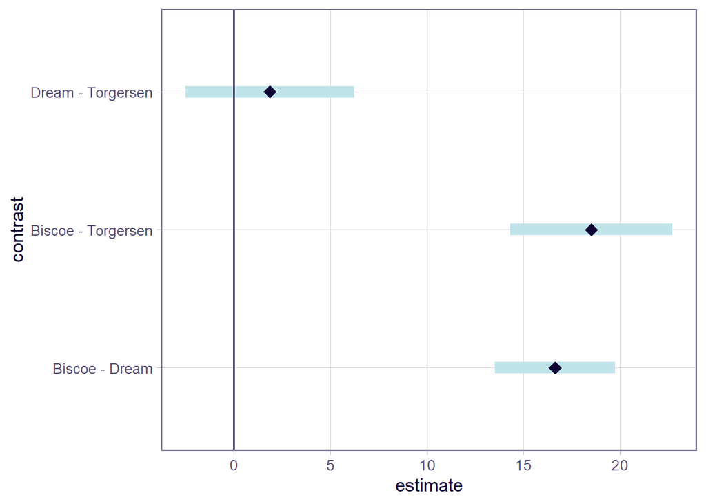

```r
plot(contraste_modelo3) +
  geom_vline(xintercept = 0)
```

Aquí podemos observar que la diferencia entre las medias de la longitud de aleta de los pingüinos de las islas “Dream” y “Torgersen” traslapa la línea del cero (no es estadísticamente significativa).

Volver arriba

Inicio